# Preprocessing, Linear Modelling and Batch effect

Shubham Gupta

August 7, 2016

Clean the global environment and set up plot settings

```r
rm(list = ls())
tropical=  c('darkorange', 'dodgerblue', 'hotpink', 'limegreen', 'yellow')
palette(tropical)
par(pch = 19)
```

### Load libraries

```r
library(gplots)
library(devtools)
library(Biobase)
library(preprocessCore)
library(broom)
library(knitr)
library(limma)
library(snpStats)
library(bladderbatch)
library(sva)
```

## Data Preprocessing

Load dataset: This is combination of two different datasets. Two different population measurements from two different labs.

```r
con =url("http://bowtie-bio.sourceforge.net/recount/ExpressionSets/montpick_eset.RData")
load(file=con)
close(con)
mp = montpick.eset
pdata=pData(mp)
edata=as.data.frame(exprs(mp))
fdata = fData(mp)
```

### Perform singular value decomposition

It is very important what mean value you subtract. The PCA algorithm in R subtract column mean. And that makes sense if you want to observe variation across samples.

```r
edata = edata[rowMeans(edata)>100,]
edata = log2(edata+1)
dim(edata)
```

```
## [1] 3072  129
```

```r
edata_centered = edata - rowMeans(edata)
svd1 = svd(edata_centered)
class(svd1)
```

```
## [1] "list"
```

```r
summary(svd1)
```

```
##   Length Class  Mode
## d    129 -none- numeric
## u 396288 -none- numeric
## v  16641 -none- numeric
```

```r
names(svd1)
```

```
## [1] "d" "u" "v"
```

```r
class(svd1$d)
```

```
## [1] "numeric"
```

### Interpreting and understanding output of SVD

V = 129 x 129 so it is telling SOMETHING about variation in samples and b/w samples(analogous to covariance) across gene expression. It is most likely the principal component of Variation among samples across all genes. Similarly U tells variation of gene expressions across all samples. M = USV’  
PCA used SVD to rank the importance of features, then U matrix will have all features (columns) ranked, we choose the first k columns which represent the most important one. Remember S is diagonal matrix, therefore features are present in columns of U, not in rows of U. Rows of U don’ give any relevant information.

Similarly, columns of V are important not rows as it is after diagonal matrix S.

```r
length(svd1$d)
```

```
## [1] 129
```

```r
dim(edata)
```

```
## [1] 3072  129
```

```r
dim(svd1$v)
```

```
## [1] 129 129
```

```r
dim(svd1$u)
```

```
## [1] 3072  129
```

So this Singular value decomposition happend across samples.

### Analyzing SVD output matrices

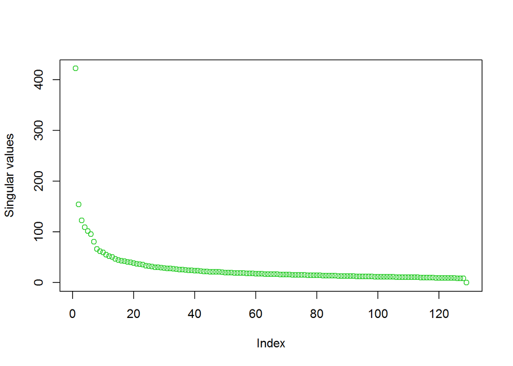

```r
plot(svd1$d, ylab = "Singular values", col = 4)
```

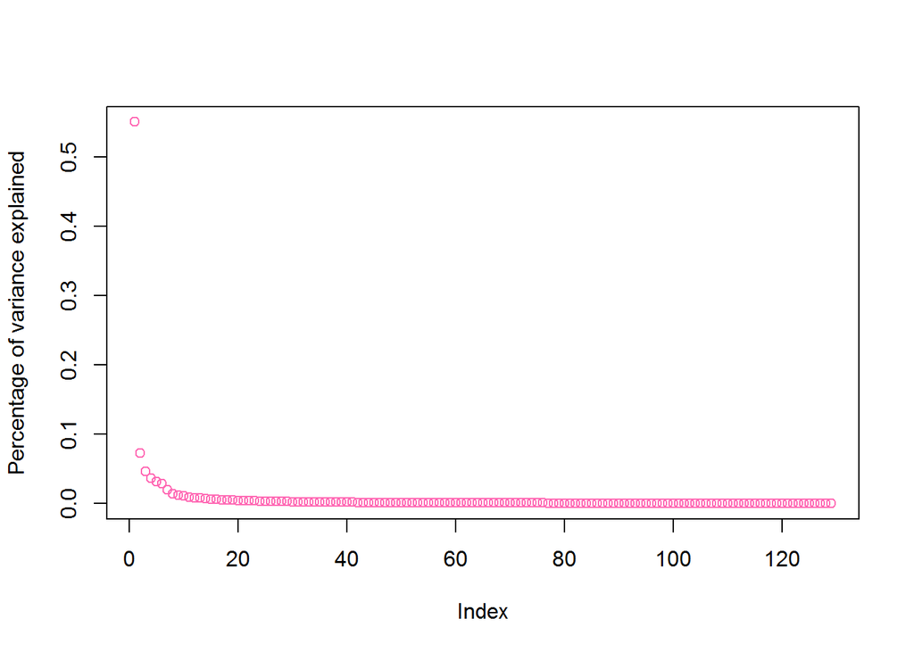

```r
plot(svd1$d^2/sum(svd1$d^2), ylab = "Percentage of variance explained", col = 3)
```

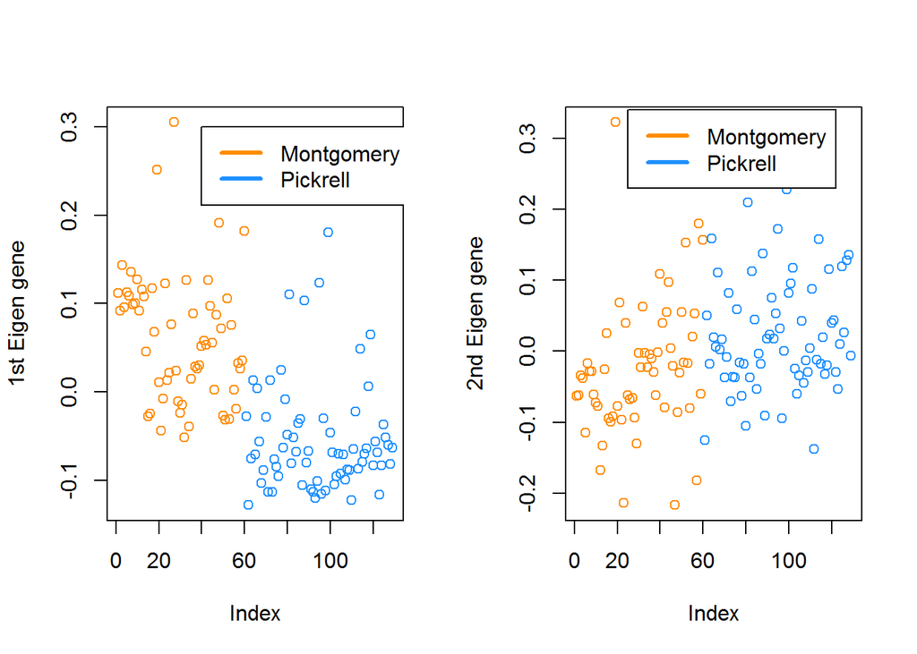

```r
# So first singular value explains more than 50% of variance so it is highly explanatory variable.
# So we need to analyze how does it look like
par(mfrow = c(1,2))
plot(svd1$v[,1], ylab = "1st Eigen gene", col = as.numeric(pdata$study))
legend(40, 0.3, legend= levels(pdata$study), col = seq_along(levels(pdata$study)), lty = 1 , lwd = 3)
plot(svd1$v[,2], ylab = "2nd Eigen gene", col = as.numeric(pdata$study))
legend(25, 0.34, legend= levels(pdata$study), col = seq_along(levels(pdata$study)), lty = 1 , lwd = 3)
```

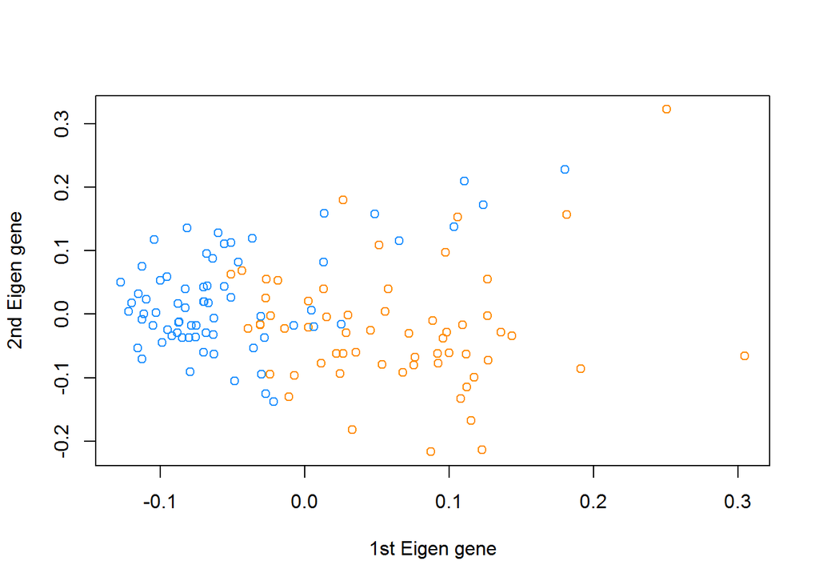

```r
par(mfrow = c(1,1))
plot(svd1$v[,1], svd1$v[,2], xlab = "1st Eigen gene", ylab = "2nd Eigen gene", col = as.numeric(pdata$study))
```

So it can be seen from last plot that first eigen gene draws very different values from both data sets. So it can make big difference which dataset is used to do analysis as selecting dataset can create big difference let alone within sample.

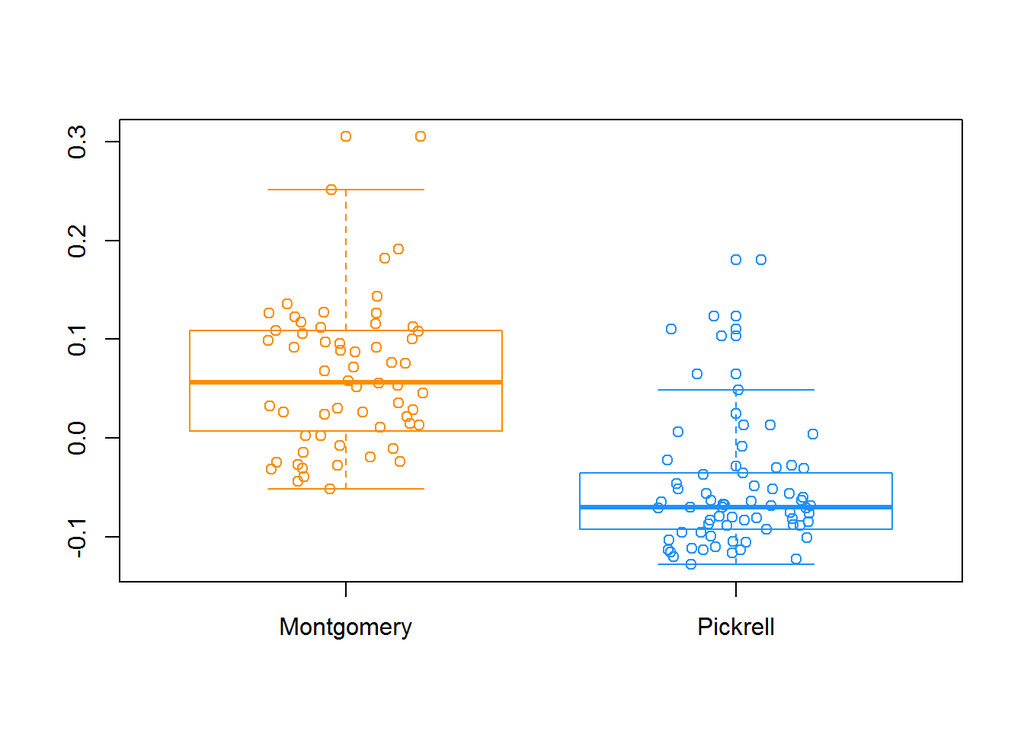

```r
boxplot(svd1$v[,1] ~ pdata$study, border = c(1,2))
# ~ signifies a formula used to split the plot into groups
# border is used to give vector for colors
points(svd1$v[,1] ~ jitter(as.numeric(pdata$study)), col = as.numeric(pdata$study)) # points is used to overlay datapoints on top of boxplot
```

Now we compare resuls with principal component analysis (PCA).

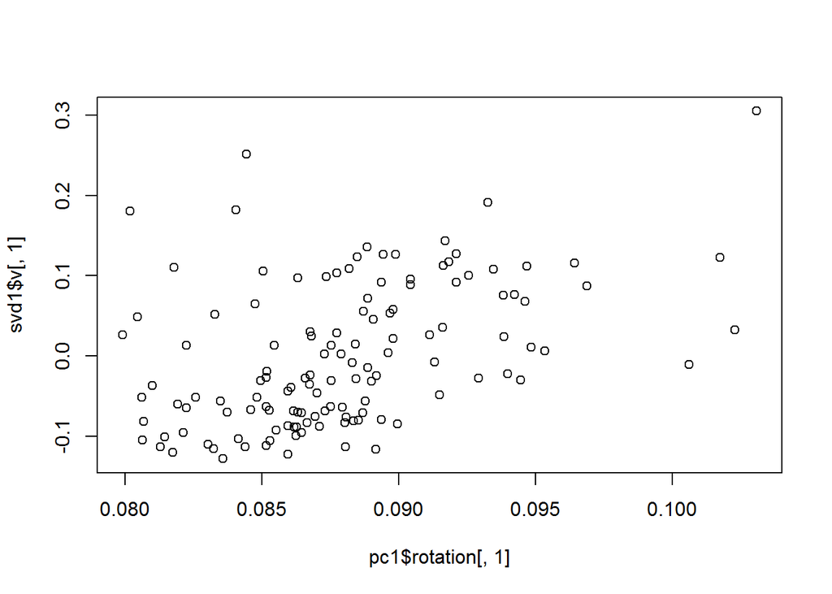

```r
pc1 = prcomp(edata, center = TRUE) # It automatically center data along columns. It subtracts column mean. It also uses SVD as that is generally the preferred method for numerical accuracy.This function find principal component of all columns
plot(pc1$rotation[,1], svd1$v[,1]) # This doesn't match because we subtracted rowMeans instead of colMeans. That subtraction gave us something else.
```

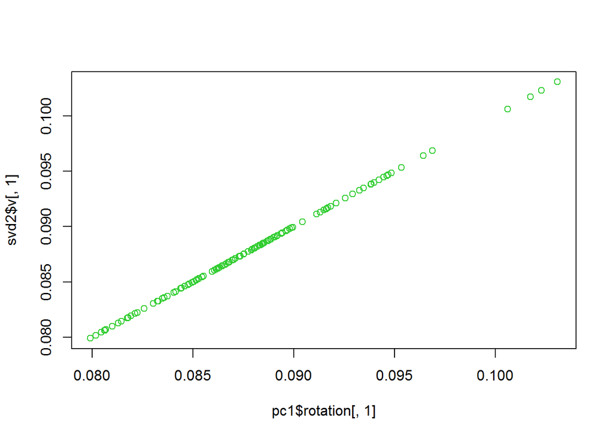

```r
edata_centered2 = t(t(edata) - colMeans(edata))
svd2 = svd(edata_centered2)
plot(pc1$rotation[,1], svd2$v[,1], col = 4)
```

Hence, this is true PC of variation between samples across gene expression.

Outliers can affect SVD output severly.

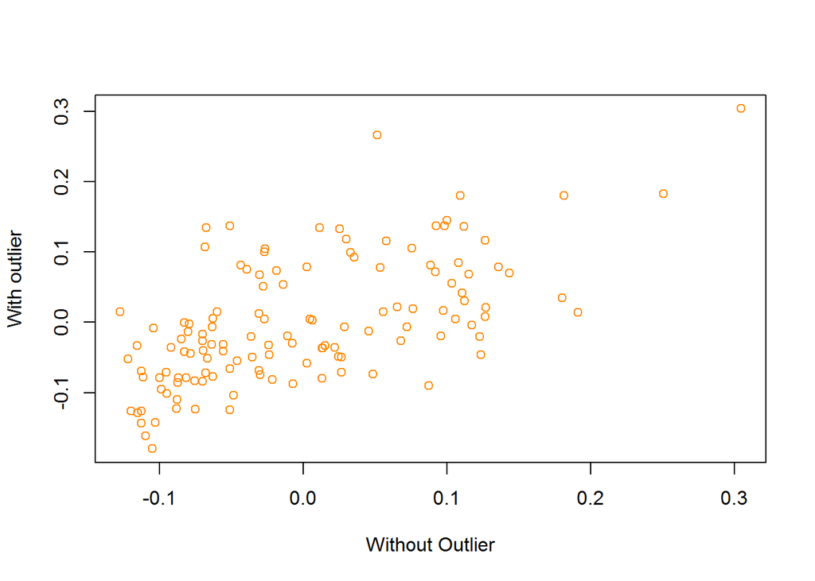

```r
edata_outlier = edata_centered
edata_outlier[6,] = edata_outlier[6,]*10000
svd3 = svd(edata_outlier)
plot(svd1$v[,1], svd3$v[,1], xlab = "Without Outlier", ylab = "With outlier", col = 1) # Don't match anymore
```

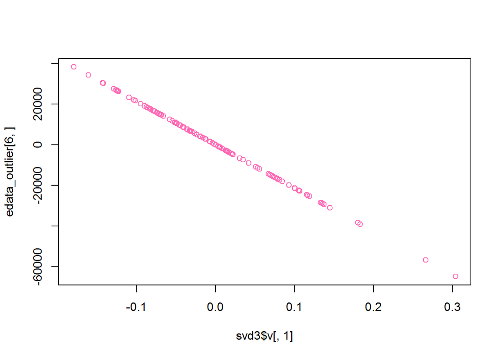

```r
plot(svd3$v[,1], edata_outlier[6,], col = 3) # Very high correlation
```

### Quantile Normalization

The point of doing quantile normalization is that you can compare different samples on the same scale without worrying about the absolute numbers. However, filtering out outliers help so your data don’t skew to one particular direction.

```r
edata=as.data.frame(exprs(mp))
edata = log2(edata +1)
dim(edata)
```

```
## [1] 52580   129
```

```r
edata = edata[rowMeans(edata)>3,]
dim(edata)
```

```
## [1] 5862  129
```

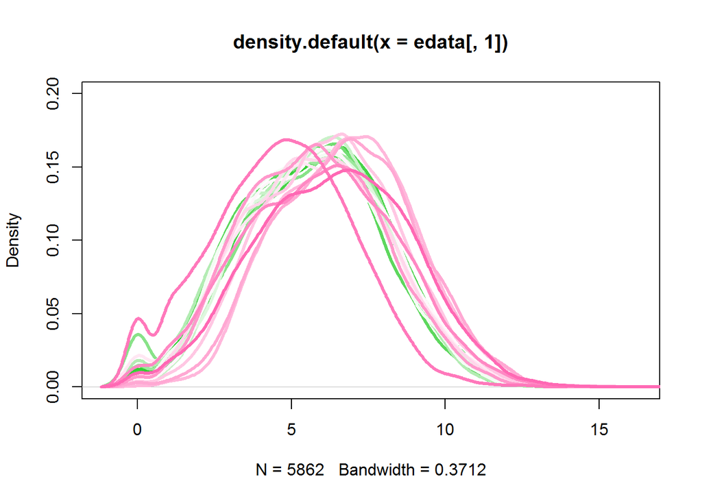

```r
coloramp = colorRampPalette(c(4,"white",3))(20) #Breaking set into 20 colors
plot(density(edata[,1]), col =coloramp[1], lwd = 3, ylim = c(0, 0.2))
for (i in 2:20){lines(density(edata[,i]), col =coloramp[i], lwd = 3)}
```

```r
colMax <- function(edata) sapply(edata, max, na.rm = FALSE)
colMax(edata[,1:20])
```

```
##  NA06985  NA06986  NA06994  NA07000  NA07037  NA07051  NA07346  NA07347
## 15.16239 15.13835 14.91312 14.24956 14.86118 15.22057 14.29856 14.54158
##  NA07357  NA10847  NA10851  NA11829  NA11830  NA11831  NA11832  NA11840
## 15.32692 14.76119 14.96294 15.26642 15.25255 15.22773 15.58449 15.83938
##  NA11881  NA11894  NA11918  NA11920
## 14.60929 14.98477 12.84412 15.82090
```

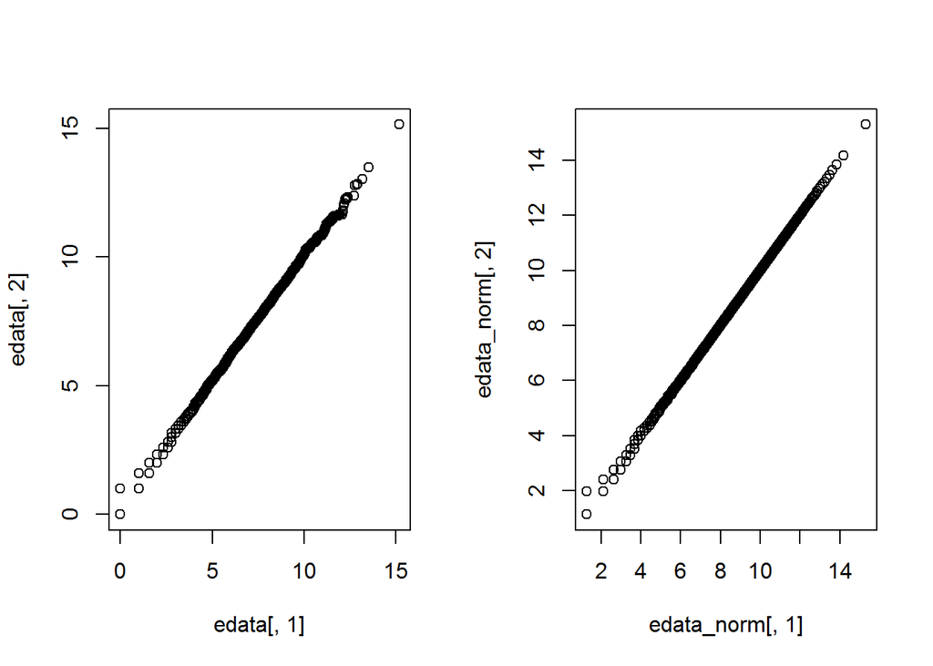

```r
edata_norm = normalize.quantiles(as.matrix(edata))
par(mfrow = c(1,2))
qqplot(edata[,1], edata[,2])
qqplot(edata_norm[,1], edata_norm[,2]) # In general, low-expressing data tends to be more noisy than the high-expression one. It could also be intrinsic to biological phenomena.
```

```r
par(mfrow = c(1,1))
dim(edata_norm)
```

```
## [1] 5862  129
```

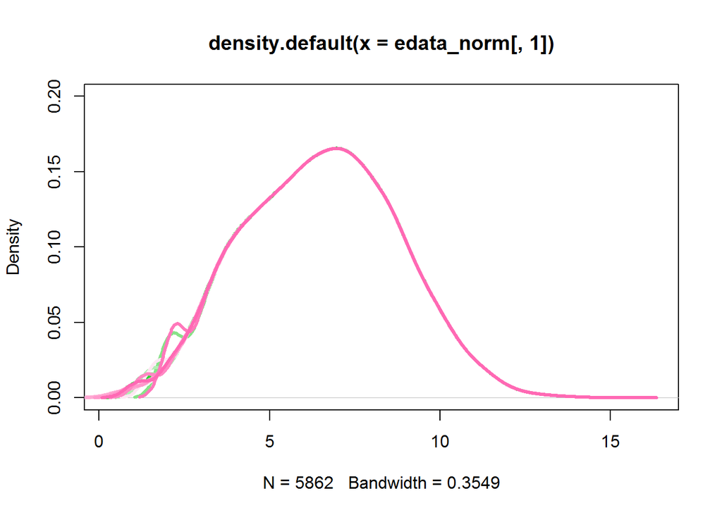

```r
plot(density(edata_norm[,1]), col =coloramp[1], lwd = 3, ylim = c(0, 0.2))
for (i in 2:20){lines(density(edata_norm[,i]), col =coloramp[i], lwd = 3)}
```

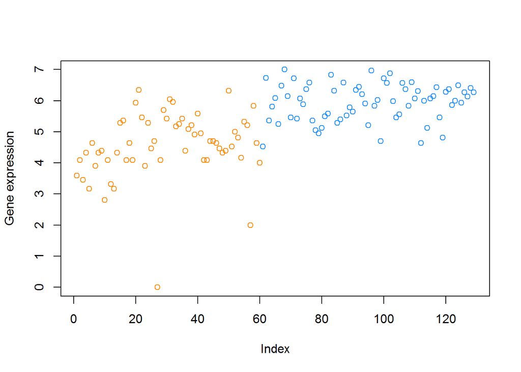

```r
x = as.matrix(edata)
plot(x[1,], ylab = "Gene expression", col = as.numeric(pdata$study))
```

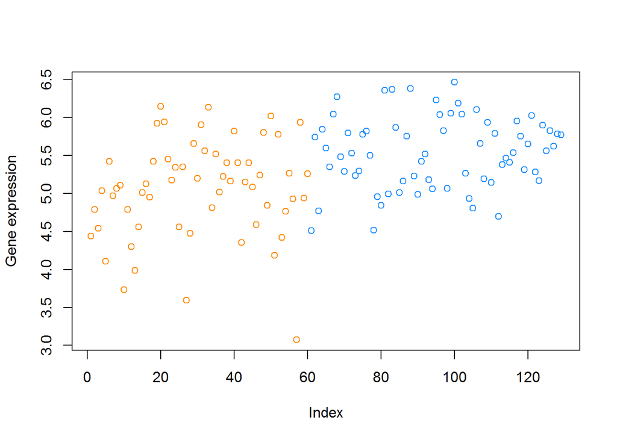

```r
plot(edata_norm[1,], ylab = "Gene expression", col = as.numeric(pdata$study)) # It hasn't removed gene by gene variation, so it is good.
```

Now, one can do SVD to solidify that gene to gen variability is still present. so, by quantile normalization we have removed some technical artefacts but data still has batch effect or other kind of artefacts.

## Linear Modelling

Models for **lm** are specified symbolically. A typical **model formula** has the form *response* ~ *terms* where *response* is the (numeric) response vector (y-axis) and terms/ explanatory variable (x-axis) is a series of terms which specifies a linear predictor for *response*. If *response* is a matrix a linear model is fitted separately by least-squares to each column of the matrix.

```r
con =url("http://bowtie-bio.sourceforge.net/recount/ExpressionSets/bodymap_eset.RData")
load(file=con)
close(con)
bm = bodymap.eset
pdata=pData(bm)
edata=as.data.frame(exprs(bm))
dim(edata)
```

```
## [1] 52580    19
```

```r
edata = as.matrix(edata)
plot(edata[1,] ~ pdata$age, col = 3, ylim = c(-1, 2400))
Lm1 = lm(edata[1,] ~ pdata$age) #Age is a quantitative covariate here.
Lm1
```

```
##
## Call:
## lm(formula = edata[1, ] ~ pdata$age)
##
## Coefficients:
## (Intercept)    pdata$age
##     2187.91       -23.25
```

```r
tidy(Lm1)
```

```
##          term   estimate  std.error statistic      p.value
## 1 (Intercept) 2187.90554 402.998816  5.429062 8.884114e-05
## 2   pdata$age  -23.24999   6.390269 -3.638343 2.686225e-03
```

```r
abline(Lm1, col = 2, lwd =2) #lm function removed NA values already
edata[1,]
```

```
## ERS025098 ERS025092 ERS025085 ERS025088 ERS025089 ERS025082 ERS025081
##      1354       216       215       924       725       125       796
## ERS025096 ERS025099 ERS025086 ERS025084 ERS025087 ERS025093 ERS025083
##      1954       815       249      4614      6548      5030      1450
## ERS025095 ERS025097 ERS025094 ERS025090 ERS025091
##       781        69      1888       983         3
```

```r
pdata$age
```

```
##  [1] 73 60 77 29 68 77 60 37 65 86 NA NA NA 47 73 77 19 60 58
```

```r
x = edata[1, -c(11,12,13)]
y = pdata$age[!is.na(pdata$age)]
mean1 = mean(x)
Lm2 = lm(x ~ y)
Lm2
```

```
##
## Call:
## lm(formula = x ~ y)
##
## Coefficients:
## (Intercept)            y
##     2187.91       -23.25
```

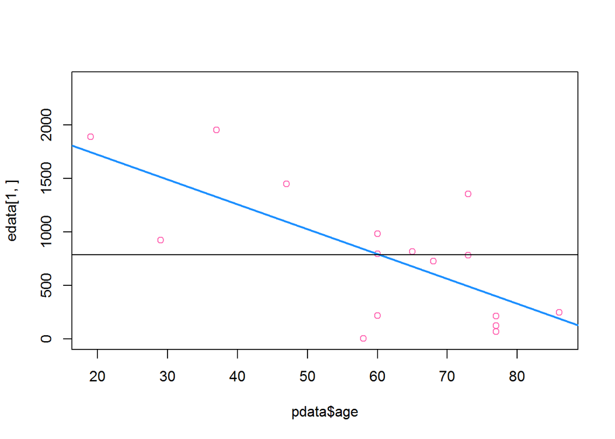

```r
abline(h = mean1)
```

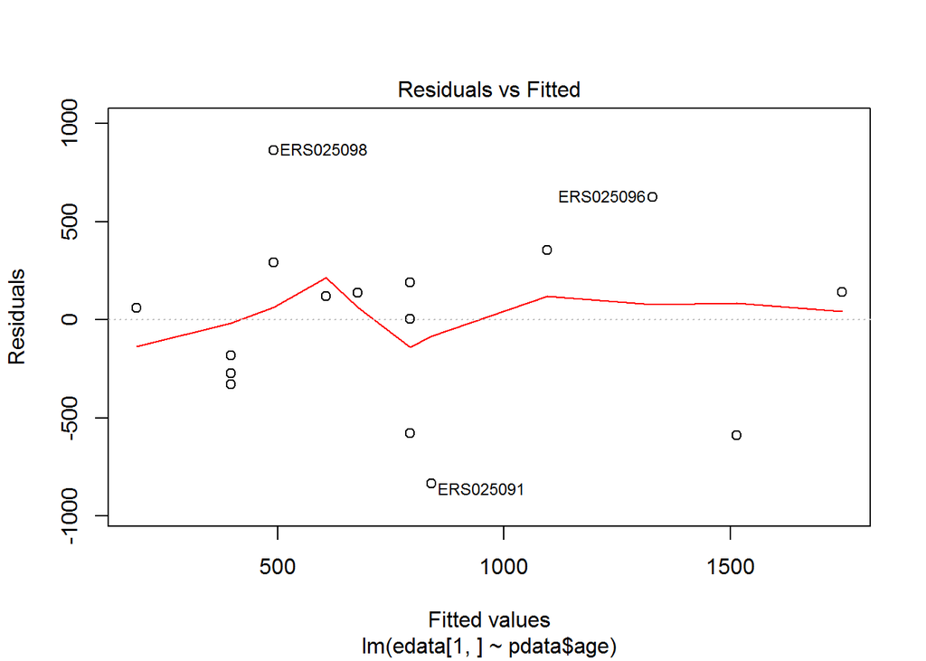

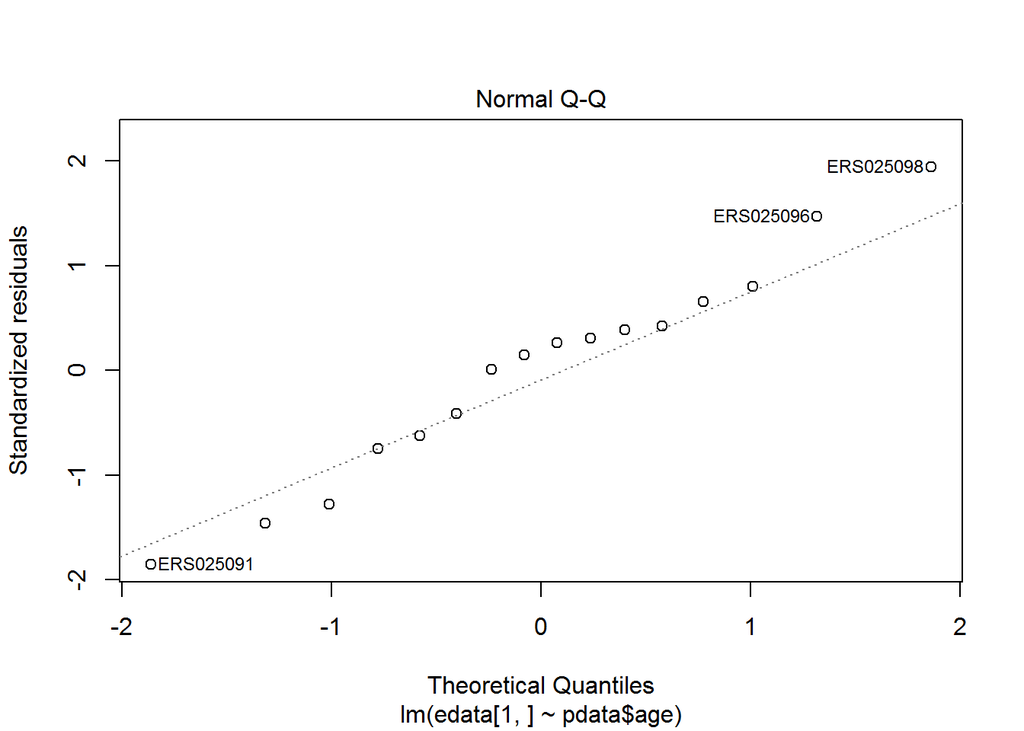

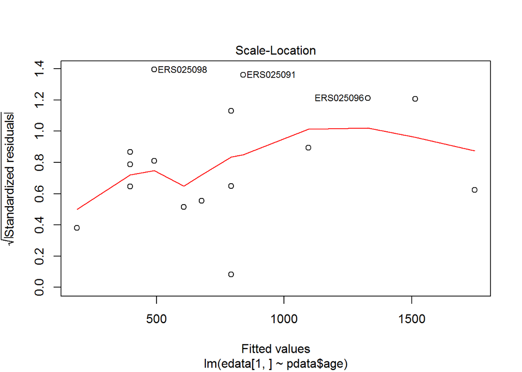

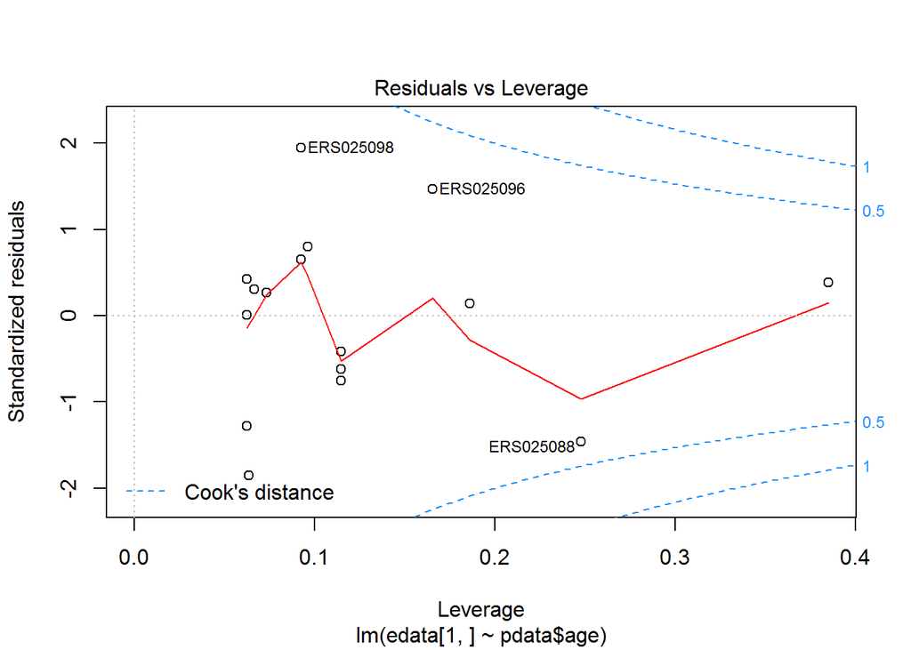

```r
plot(Lm1) # These plots tells us about residuals. First two plots are very important.
```

```r
summary(Lm1) #Important
```

```
##
## Call:
## lm(formula = edata[1, ] ~ pdata$age)
##
## Residuals:
##     Min      1Q  Median      3Q     Max
## -836.41 -286.66   89.34  215.16  863.34
##
## Coefficients:
##             Estimate Std. Error t value Pr(>|t|)
## (Intercept)  2187.91     403.00   5.429 8.88e-05 ***
## pdata$age     -23.25       6.39  -3.638  0.00269 **
## ---
## Signif. codes:  0 '***' 0.001 '**' 0.01 '*' 0.05 '.' 0.1 ' ' 1
##
## Residual standard error: 465.7 on 14 degrees of freedom
##   (3 observations deleted due to missingness)
## Multiple R-squared:  0.486,  Adjusted R-squared:  0.4493
## F-statistic: 13.24 on 1 and 14 DF,  p-value: 0.002686
```

```r
pdata$gender
```

```
##  [1] F    M    F    F    F    M    F    M    M    F    <NA> <NA> <NA> F
## [15] M    M    M    F    M
## Levels: F M
```

```r
table(pdata$gender)
```

```
##
## F M
## 8 8
```

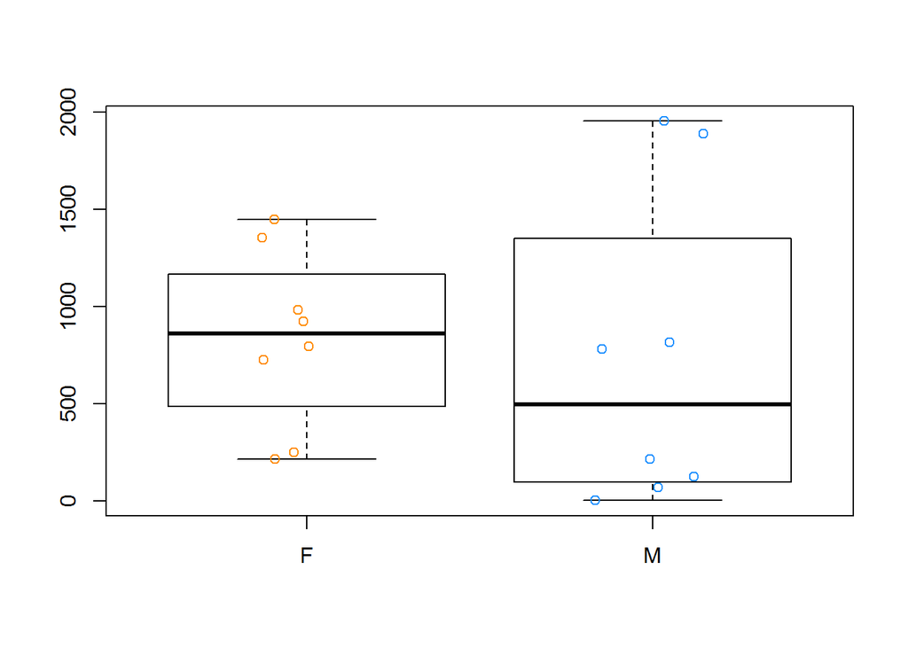

```r
boxplot(edata[1,] ~ pdata$gender)
points(edata[1,] ~ jitter(as.numeric(pdata$gender)), col = as.numeric(pdata$gender))
```

```r
# dummy variables are variables equal to 1 if something is TRUE
dummy_m = pdata$gender =="M" # For female it could be done similarly
dummy_m
```

```
##  [1] FALSE  TRUE FALSE FALSE FALSE  TRUE FALSE  TRUE  TRUE FALSE    NA
## [12]    NA    NA FALSE  TRUE  TRUE  TRUE FALSE  TRUE
```

```r
dummy_m*1
```

```
##  [1]  0  1  0  0  0  1  0  1  1  0 NA NA NA  0  1  1  1  0  1
```

```r
Lm2 = lm(edata[1,] ~ pdata$gender)
Lm2
```

```
##
## Call:
## lm(formula = edata[1, ] ~ pdata$gender)
##
## Coefficients:
##   (Intercept)  pdata$genderM
##         837.0         -105.6
```

```r
tidy(Lm2)
```

```
##            term estimate std.error  statistic     p.value
## 1   (Intercept)  837.000  228.8055  3.6581292 0.002582905
## 2 pdata$genderM -105.625  323.5798 -0.3264264 0.748930374
```

```r
model.matrix(Lm2) # This is what lm function does. It converts factor variable to the dummy variable
```

```
##           (Intercept) pdata$genderM
## ERS025098           1             0
## ERS025092           1             1
## ERS025085           1             0
## ERS025088           1             0
## ERS025089           1             0
## ERS025082           1             1
## ERS025081           1             0
## ERS025096           1             1
## ERS025099           1             1
## ERS025086           1             0
## ERS025083           1             0
## ERS025095           1             1
## ERS025097           1             1
## ERS025094           1             1
## ERS025090           1             0
## ERS025091           1             1
## attr(,"assign")
## [1] 0 1
## attr(,"contrasts")
## attr(,"contrasts")$`pdata$gender`
## [1] "contr.treatment"
```

```r
table(pdata$tissue.type) # Likewise you can define dummy variables for all tissue type
```

```
##
##          adipose          adrenal            brain           breast
##                1                1                1                1
##            colon            heart           kidney            liver
##                1                1                1                1
##             lung        lymphnode          mixture            ovary
##                1                1                3                1
##         prostate  skeletal_muscle           testes          thyroid
##                1                1                1                1
## white_blood_cell
##                1
```

```r
dummy_1 = pdata$tissue.type == "adipose"
dummy_1
```

```
##  [1]  TRUE FALSE FALSE FALSE FALSE FALSE FALSE FALSE FALSE FALSE FALSE
## [12] FALSE FALSE FALSE FALSE FALSE FALSE FALSE FALSE
```

```r
dummy_2 = pdata$tissue.type == "mixture"
dummy_2
```

```
##  [1] FALSE FALSE FALSE FALSE FALSE FALSE FALSE FALSE FALSE FALSE  TRUE
## [12]  TRUE  TRUE FALSE FALSE FALSE FALSE FALSE FALSE
```

```r
tidy(lm(edata[1,] ~ pdata$tissue.type)) # On looking closely, the baseline is the value for adipose and all other tissue type tell diffrence with that value. adrenal = 1354 + (-1138)
```

```
##                                 term  estimate std.error   statistic
## 1                        (Intercept)  1354.000  1017.983  1.33008119
## 2           pdata$tissue.typeadrenal -1138.000  1439.645 -0.79047247
## 3             pdata$tissue.typebrain -1139.000  1439.645 -0.79116709
## 4            pdata$tissue.typebreast  -430.000  1439.645 -0.29868468
## 5             pdata$tissue.typecolon  -629.000  1439.645 -0.43691317
## 6             pdata$tissue.typeheart -1229.000  1439.645 -0.85368248
## 7            pdata$tissue.typekidney  -558.000  1439.645 -0.38759547
## 8             pdata$tissue.typeliver   600.000  1439.645  0.41676932
## 9              pdata$tissue.typelung  -539.000  1439.645 -0.37439777
## 10        pdata$tissue.typelymphnode -1105.000  1439.645 -0.76755016
## 11          pdata$tissue.typemixture  4043.333  1175.465  3.43977205
## 12            pdata$tissue.typeovary    96.000  1439.645  0.06668309
## 13         pdata$tissue.typeprostate  -573.000  1439.645 -0.39801470
## 14  pdata$tissue.typeskeletal_muscle -1285.000  1439.645 -0.89258095
```

[output cut: 21 more lines]

### Adjusting for variables:

```r
Lm3 = lm(edata[1,] ~ pdata$age + pdata$gender)
tidy(Lm3) # This fits the same relationship for males and females
```

```
##            term  estimate  std.error  statistic     p.value
## 1   (Intercept) 2331.5814 438.181127  5.3210448 0.000138739
## 2     pdata$age  -23.9133   6.488058 -3.6857414 0.002743642
## 3 pdata$genderM -207.2565 236.430512 -0.8766066 0.396610372
```

```r
Lm4 = lm(edata[1,] ~ pdata$age*pdata$gender) # This is interaction term
tidy(Lm4) #Now you have two lines(one for male and one for female)
```

```
##                      term   estimate  std.error statistic    p.value
## 1             (Intercept) 1679.37818 610.165662  2.752332 0.01752641
## 2               pdata$age  -13.47805   9.425164 -1.430007 0.17823223
## 3           pdata$genderM  912.51047 793.378850  1.150157 0.27248454
## 4 pdata$age:pdata$genderM  -18.46210  12.536549 -1.472662 0.16658057
```

### Effect of Outlier

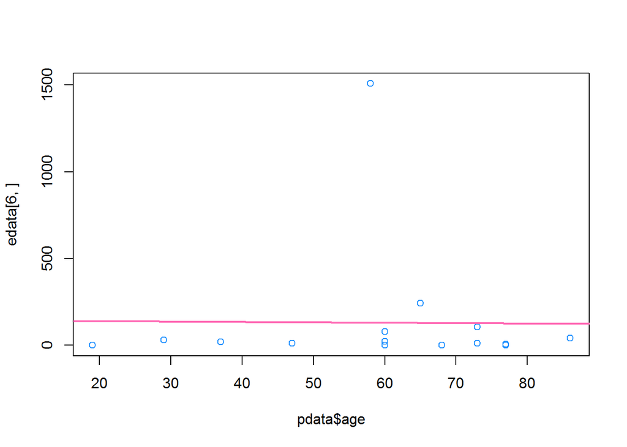

```r
Lm5 = lm(edata[6,] ~ pdata$age)
plot(edata[6,] ~ pdata$age, col = 2)
abline(Lm5, col = 3, lwd =2) # Here we can't see the effect of outlier whether it is pulled northward
```

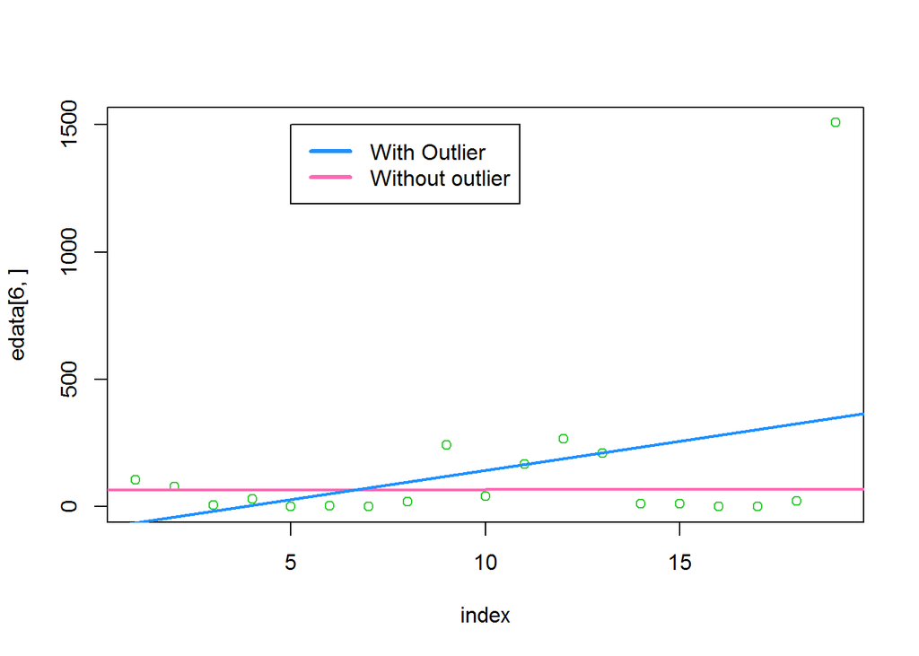

```r
index = 1:19
plot(index, edata[6, ], col = 4) # Now we know the index
Lm6 = lm(edata[6,-19] ~ index[-19])
abline(Lm6, col = 3, lwd =2)
Lm7 = lm(edata[6,] ~ index)
abline(Lm7, col = 2, lwd =2) #This shows that outier is indeed pulling up the line, Hence your model depends on covariate.
legend(5,1500, legend = c("With Outlier", "Without outlier"), col = c(2,3), lwd = 3)
```

### Investigating residuals

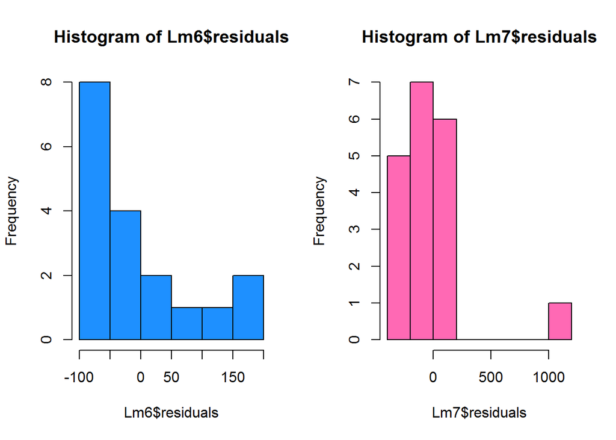

```r
par(mfrow = c(1,2))
hist(Lm6$residuals, col = 2)
hist(Lm7$residuals, col = 3) # Outlier contributes a very large residual
```

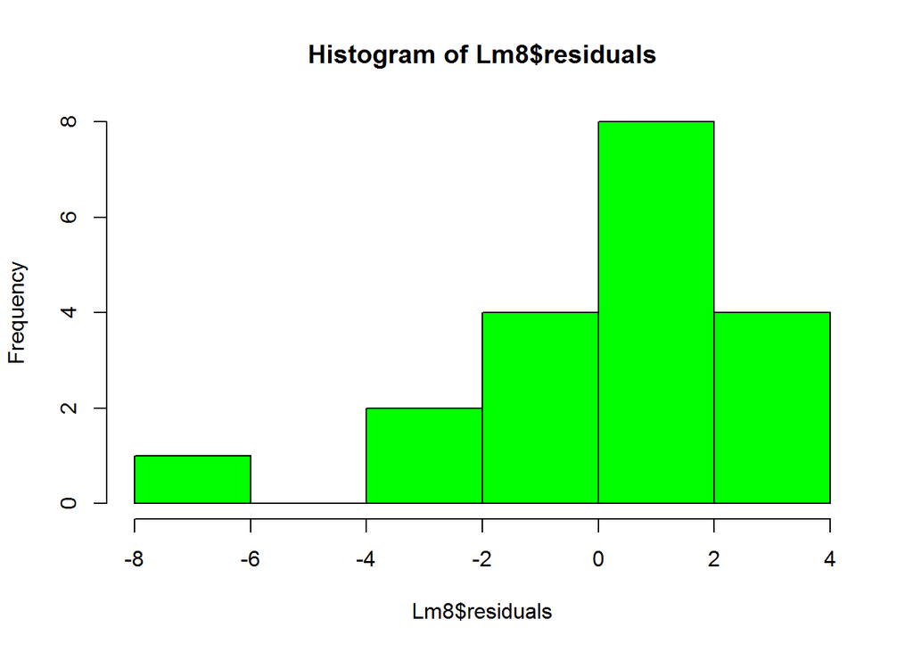

```r
gene1 = log2(edata[1,])+1
Lm8 = lm(gene1 ~ index)
par(mfrow = c(1,1))
hist(Lm8$residuals, col = "green")
```

```r
Lm9 = lm(gene1 ~ pdata$tissue.type +pdata$age)
tidy(Lm9)
```

```
##                                 term    estimate std.error statistic
## 1                        (Intercept) 11.40301202       NaN       NaN
## 2           pdata$tissue.typeadrenal -2.64812452       NaN       NaN
## 3             pdata$tissue.typebrain -2.65481917       NaN       NaN
## 4            pdata$tissue.typebreast -0.55126298       NaN       NaN
## 5             pdata$tissue.typecolon -0.90117484       NaN       NaN
## 6             pdata$tissue.typeheart -3.43722774       NaN       NaN
## 7            pdata$tissue.typekidney -0.76638740       NaN       NaN
## 8             pdata$tissue.typeliver  0.52920273       NaN       NaN
## 9              pdata$tissue.typelung -0.73235577       NaN       NaN
## 10        pdata$tissue.typelymphnode -2.44301009       NaN       NaN
## 11            pdata$tissue.typeovary  0.09882516       NaN       NaN
## 12         pdata$tissue.typeprostate -0.79383329       NaN       NaN
## 13  pdata$tissue.typeskeletal_muscle -4.29448757       NaN       NaN
## 14           pdata$tissue.typetestes  0.47963103       NaN       NaN
```

[output cut: 19 more lines]

```r
# Many coefficients are not defined because there are too many covariates here. You are fitting too many parameters (18) in few data points (16)
# Remember there were 17 tissue types, since they are not quantitative it creates 17 columns for them and 18th is for age. Hence dimension of model matrix is 16 X 18
dim(model.matrix(~ pdata$tissue.type +pdata$age))
```

```
## [1] 16 18
```

```r
dim(model.matrix(Lm9)) #This is one less as we know one dummy variable goes into baseline.
```

```
## [1] 16 17
```

So, one needs to be careful that they don’t have covariates with too many levels. Detailed information about model matrix can be found at http://www.stat.wisc.edu/~st849-1/Rnotes/ModelMatrices.html#sec-1

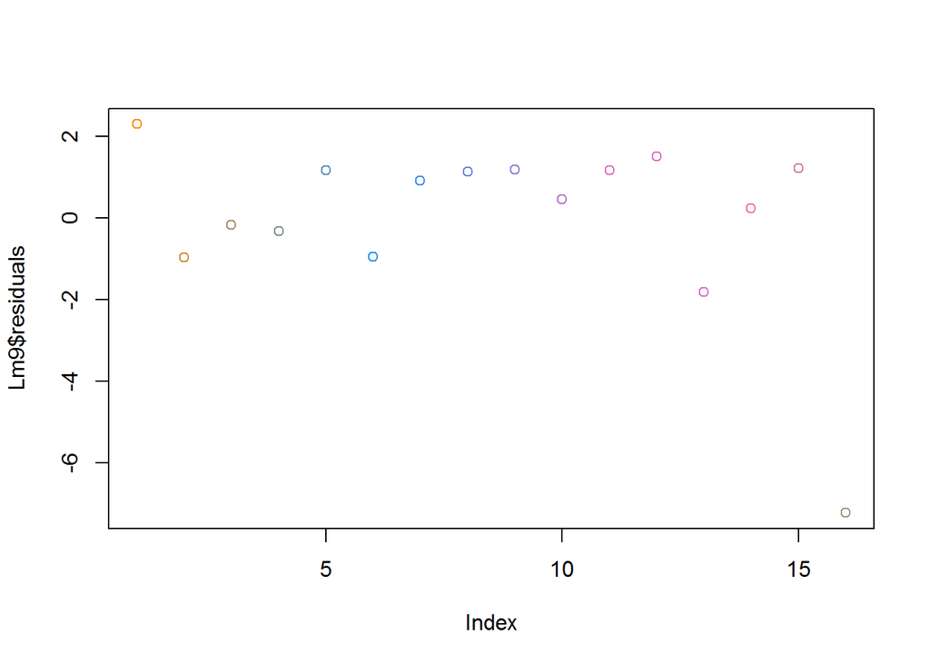

```r
coloramp = colorRampPalette(1:4)(17) # Because we have 17 tissue types we want to plot against
Lm9 = lm(gene1 ~ pdata$age)
plot( Lm9$residuals, col = coloramp[as.numeric(pdata$tissue.type)])
```

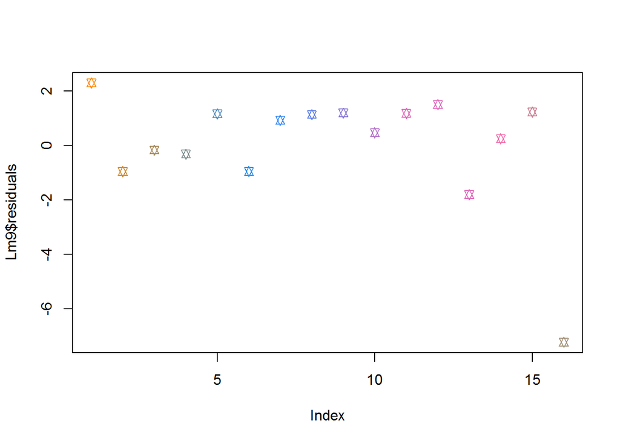

```r
par(pch = 11)
plot(Lm9$residuals, col = coloramp[as.numeric(pdata$tissue.type)]) # By this you can get which residual is associated with what tissue type (covariate)
```

## Regression Modelling

First load data for regression analysis

```r
par(pch = 21)
con =url("http://bowtie-bio.sourceforge.net/recount/ExpressionSets/bottomly_eset.RData")
load(file=con)
close(con)
bot = bottomly.eset
pdata=pData(bot)
edata = as.matrix(exprs(bot))
fdata = fData(bot)
```

Regression model:

```r
edata = log2(edata + 1)
edata = edata[rowMeans(edata)> 10, ]
dim(edata)
```

```
## [1] 1049   21
```

```r
# So now we have to fit 1000 times. We need to create a common model matrix because we want to fit exact same model for every single gene.

mod = model.matrix(~ pdata$strain)
names(mod)
```

```r
fit = lm.fit(mod, t(edata))
names(fit)
```

```
## [1] "coefficients"  "residuals"     "effects"       "rank"
## [5] "fitted.values" "assign"        "qr"            "df.residual"
```

```r
class(fit)
```

```
## [1] "list"
```

```r
class(fit$coefficients)
```

```
## [1] "matrix"
```

```r
dim(fit$coefficients)
```

```
## [1]    2 1049
```

```r
fit$coefficients[,1]
```

```
##        (Intercept) pdata$strainDBA/2J
##         10.4116634          0.3478919
```

```r
tidy(lm(edata[1,] ~ pdata$strain)) # Same values from both methods.
```

```
##                 term   estimate std.error statistic      p.value
## 1        (Intercept) 10.4116634 0.1516267 68.666422 3.097880e-24
## 2 pdata$strainDBA/2J  0.3478919 0.2095024  1.660563 1.132148e-01
```

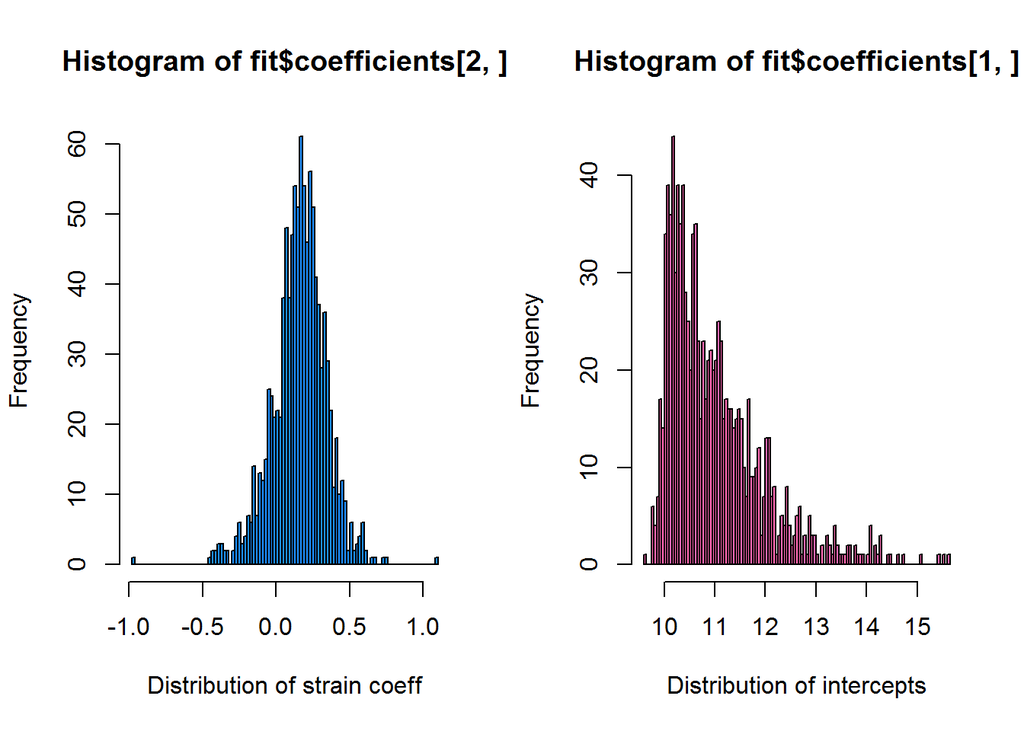

```r
# lm.fit is much much faster as you can fit multiple models at the same time
par(mfrow= c(1,2))
hist(fit$coefficients[2,], breaks = 100, col = 2, xlab = "Distribution of strain coeff")
# This way you can visualize distribution of intercepts and slopes to see how lines wouldd like.
hist(fit$coefficients[1,], breaks = 100, col = 3, xlab = "Distribution of intercepts")
```

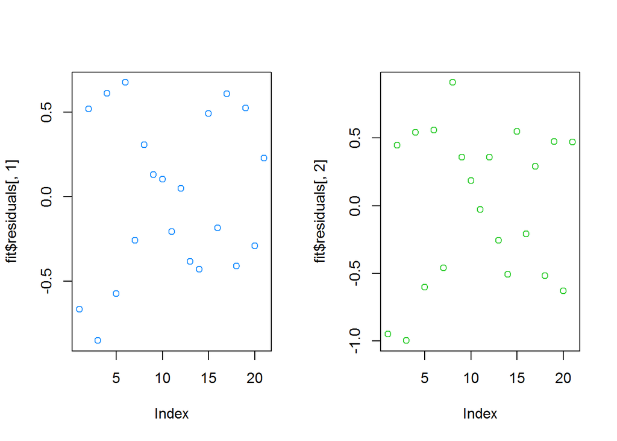

```r
#Similarly residuals can be visualized.
plot(fit$residuals[,1], col = 2)
plot(fit$residuals[,2], col = 4)
```

Now we can analyze regression model for adjusted model fit.

```r
Lane_covariate = as.factor(pdata$lane.number) #Covariate has to be unique
mod_adj = model.matrix(~ pdata$strain + Lane_covariate)
fit_adj = lm.fit(mod_adj, t(edata))
names(fit_adj)
```

```
## [1] "coefficients"  "residuals"     "effects"       "rank"
## [5] "fitted.values" "assign"        "qr"            "df.residual"
```

```r
dim(fit_adj$coefficients)
```

```
## [1]    8 1049
```

```r
fit_adj$coefficients[,1] # Now we have intercepts and other adjustment variables as well
```

```
##        (Intercept) pdata$strainDBA/2J    Lane_covariate2
##        10.31359781         0.28934825         0.05451431
##    Lane_covariate3    Lane_covariate5    Lane_covariate6
##         0.02502244         0.07200502         0.38038016
##    Lane_covariate7    Lane_covariate8
##         0.21815863         0.15103858
```

```r
dim(mod)
```

```
## [1] 21  2
```

```r
dim(mod_adj)
```

```
## [1] 21  8
```

Now we will use functions given in Limma package for model fit

```r
lim_fit = lmFit(edata, mod_adj)
names(lim_fit)
```

```
##  [1] "coefficients"     "rank"             "assign"
##  [4] "qr"               "df.residual"      "sigma"
##  [7] "cov.coefficients" "stdev.unscaled"   "pivot"
## [10] "Amean"            "method"           "design"
```

```r
names(fit_adj)# So there is some more information with Limma'a lmFit function
```

```
## [1] "coefficients"  "residuals"     "effects"       "rank"
## [5] "fitted.values" "assign"        "qr"            "df.residual"
```

```r
dim(lim_fit$coefficients)
```

```
## [1] 1049    8
```

```r
lim_fit$coefficients[1,] #So output is same just there placement is different
```

```
##        (Intercept) pdata$strainDBA/2J    Lane_covariate2
##        10.31359781         0.28934825         0.05451431
##    Lane_covariate3    Lane_covariate5    Lane_covariate6
##         0.02502244         0.07200502         0.38038016
##    Lane_covariate7    Lane_covariate8
##         0.21815863         0.15103858
```

## Batch effect and Confounders

The biggest confounder in genomics is Batch effect. Most common reason for false positive in genomics is batch effect.

```r
data(bladderdata)
pdata = pData(bladderEset)
edata = exprs(bladderEset)
class(edata)
```

```
## [1] "matrix"
```

```r
class(pdata)
```

```
## [1] "data.frame"
```

```r
dim(edata)
```

```
## [1] 22283    57
```

```r
head(pdata)
```

```
##              sample outcome batch cancer
## GSM71019.CEL      1  Normal     3 Normal
## GSM71020.CEL      2  Normal     2 Normal
## GSM71021.CEL      3  Normal     2 Normal
## GSM71022.CEL      4  Normal     3 Normal
## GSM71023.CEL      5  Normal     3 Normal
## GSM71024.CEL      6  Normal     3 Normal
```

```r
dim(pdata)
```

```
## [1] 57  4
```

```r
mod = model.matrix(~ as.factor(pdata$cancer) + as.factor(pdata$batch), data = pdata)
dim(mod)
```

```
## [1] 57  7
```

```r
Lm = lm.fit(mod, t(edata))
names(Lm)
```

```
## [1] "coefficients"  "residuals"     "effects"       "rank"
## [5] "fitted.values" "assign"        "qr"            "df.residual"
```

```r
dim(Lm$coefficients)
```

```
## [1]     7 22283
```

```r
rownames(Lm$coefficients)
```

```
## [1] "(Intercept)"                   "as.factor(pdata$cancer)Cancer"
## [3] "as.factor(pdata$cancer)Normal" "as.factor(pdata$batch)2"
## [5] "as.factor(pdata$batch)3"       "as.factor(pdata$batch)4"
## [7] "as.factor(pdata$batch)5"
```

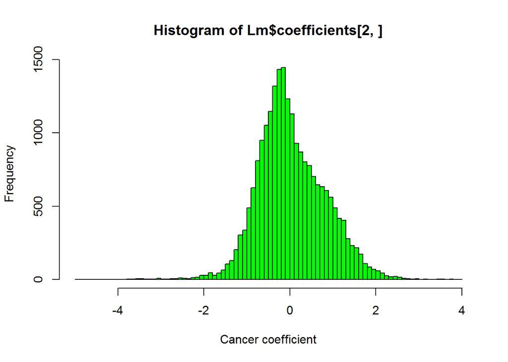

```r
hist(Lm$coefficients[2,], col = "green", breaks = 100 ,xlab = "Cancer coefficient")
```

```r
table(pdata$cancer, pdata$batch)
```

```
##
##           1  2  3  4  5
##   Biopsy  0  0  0  5  4
##   Cancer 11 14  0  0 15
##   Normal  0  4  4  0  0
```

ComBat allows users to adjust for batch effects in datasets where the batch covariate is known.

```r
modCombat = model.matrix(~1, data = pdata)
modCancer = model.matrix(~ as.factor(pdata$cancer), data = pdata)
dim(modCancer)
```

```
## [1] 57  3
```

```r
dim(modCombat)
```

```
## [1] 57  1
```

```
## Found 5 batches
## Adjusting for 0 covariate(s) or covariate level(s)
## Standardizing Data across genes
## Fitting L/S model and finding priors
```

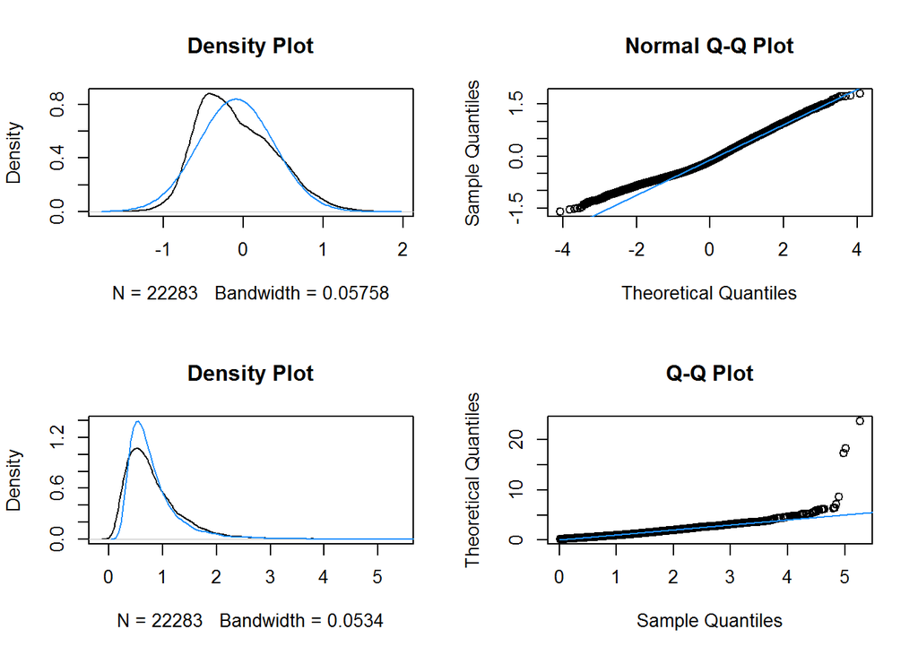

```
## Finding parametric adjustments
## Adjusting the Data
```

```r
edata_combat = ComBat(dat = edata, batch = pdata$batch, mod = modCombat, par.prior = T, prior.plots= TRUE) #It is going to regress out the batch effect from the data
```

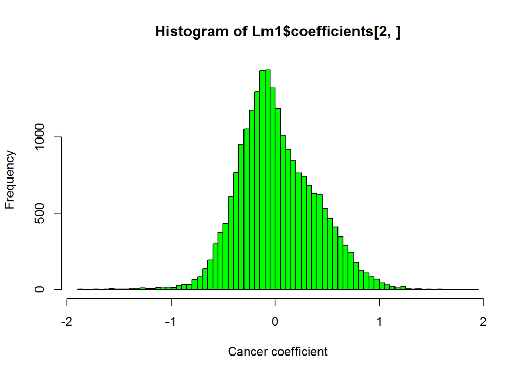

```r
Lm1 = lm.fit(modCancer, t(edata_combat))
par(mfrow = c(1,1))
hist(Lm1$coefficients[2,], col = "green", breaks = 100 ,xlab = "Cancer coefficient")
```

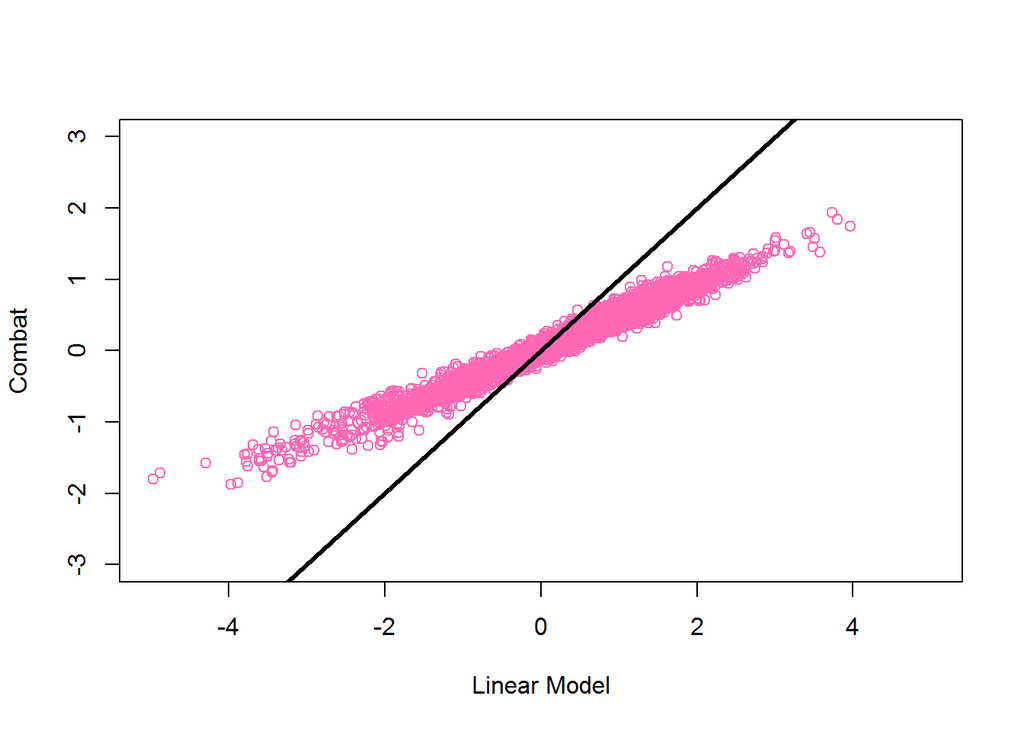

```r
plot(Lm$coefficients[2,], Lm1$coefficients[2,], xlab = "Linear Model", ylab = "Combat", col = 3, xlim = c(-5,5), ylim = c(-3,3))
abline(c(0,1), lwd = 3)
```

So combat values are less than linear model because we have done some shrinkage.  
If batch variable is not available then we may want to infer it. Here we update model instead of expression data

```r
sva1 = sva(dat= edata, mod = modCancer, mod0 = modCombat, n.sv = 2)
```

```
## Number of significant surrogate variables is:  2
## Iteration (out of 5 ):1  2  3  4  5
```

```r
class(sva1)
```

```
## [1] "list"
```

```r
names(sva1)
```

```
## [1] "sv"        "pprob.gam" "pprob.b"   "n.sv"
```

```r
summary(lm(sva1$sv ~ pdata$batch)) # 2nd surrogate variable is highly correlated to batch variable. So we can use linear model to find correlation as well.
```

```
## Response Y1 :
##
## Call:
## lm(formula = Y1 ~ pdata$batch)
##
## Residuals:
##      Min       1Q   Median       3Q      Max
## -0.26953 -0.11076  0.00787  0.10399  0.19069
##
## Coefficients:
##              Estimate Std. Error t value Pr(>|t|)
## (Intercept) -0.018470   0.038694  -0.477    0.635
## pdata$batch  0.006051   0.011253   0.538    0.593
##
## Residual standard error: 0.1345 on 55 degrees of freedom
## Multiple R-squared:  0.00523,    Adjusted R-squared:  -0.01286
## F-statistic: 0.2891 on 1 and 55 DF,  p-value: 0.5929
##
##
## Response Y2 :
##
## Call:
## lm(formula = Y2 ~ pdata$batch)
##
## Residuals:
##      Min       1Q   Median       3Q      Max
## -0.23973 -0.07467 -0.02157  0.08116  0.25629
##
## Coefficients:
##              Estimate Std. Error t value Pr(>|t|)
## (Intercept)  0.121112   0.034157   3.546 0.000808 ***
## pdata$batch -0.039675   0.009933  -3.994 0.000194 ***
## ---
## Signif. codes:  0 '***' 0.001 '**' 0.01 '*' 0.05 '.' 0.1 ' ' 1
##
## Residual standard error: 0.1187 on 55 degrees of freedom
## Multiple R-squared:  0.2248, Adjusted R-squared:  0.2107
## F-statistic: 15.95 on 1 and 55 DF,  p-value: 0.0001945
```

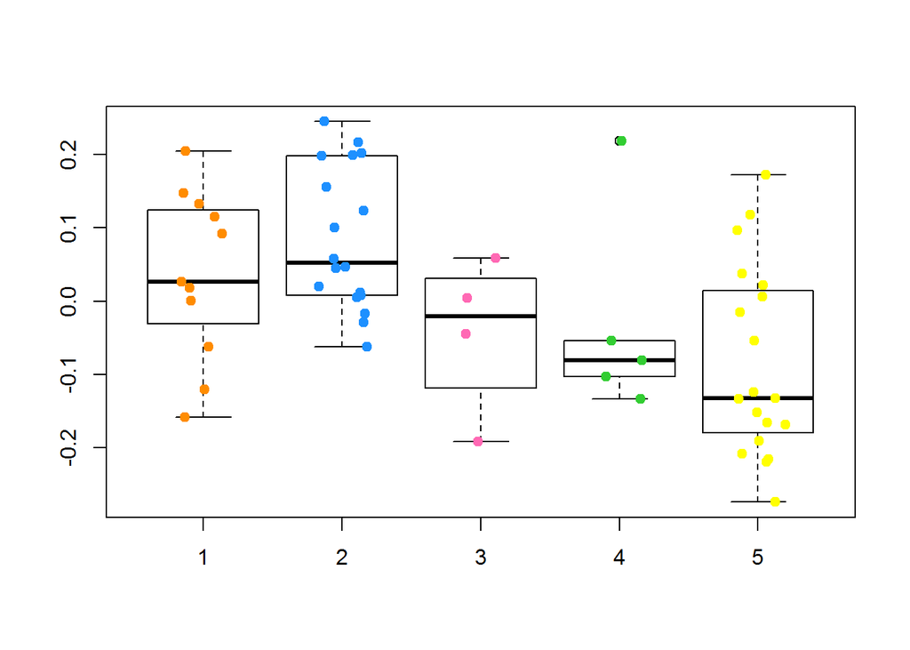

```r
boxplot(sva1$sv[,2] ~ as.factor(pdata$batch))
par(pch = 19)
points(sva1$sv[,2] ~ jitter(as.numeric(pdata$batch)), col = as.numeric(pdata$batch))
```

```r
#With SVA we don't clean data set. We just have identified new covariate which we will include in our model.
cb_mod = cbind(modCancer, sva1$sv) #Combine by columns
dim(cb_mod)
```

```
## [1] 57  5
```

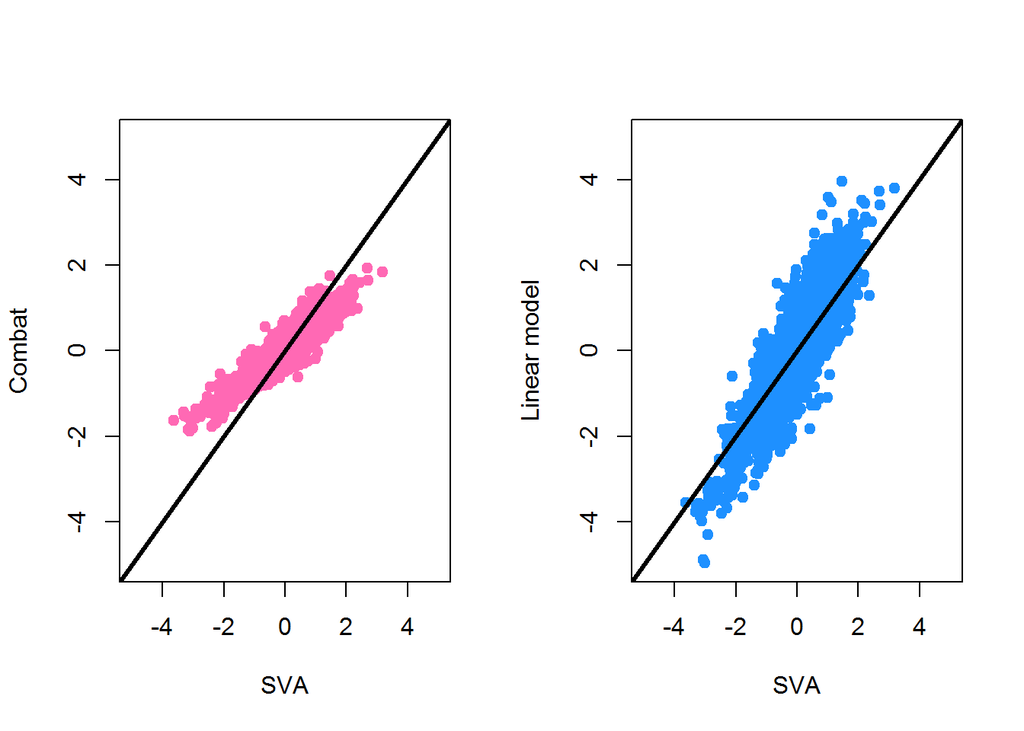

```r
fitsv = lm.fit(cb_mod, t(edata))
par(mfrow= c(1,2))
plot(fitsv$coefficients[2,], Lm1$coefficients[2,], xlab = "SVA", ylab = "Combat", col = 3, xlim = c(-5,5), ylim = c(-5,5))
abline(c(0,1), lwd = 3) # Combat is shrunk so seems less correlated
plot(fitsv$coefficients[2,], Lm$coefficients[2,], xlab = "SVA", ylab = "Linear model", col = 2, xlim = c(-5,5), ylim = c(-5,5))
abline(c(0,1), lwd = 3)
```

```r
par(mfrow= c(1,1))
```

Batch effect could be technological artifacts or could be biological condounders.

```r
data(for.exercise) #Loads three data sets: snps.10, snp.support and subject.support
class(subject.support)
```

```
## [1] "data.frame"
```

```r
names(subject.support)#cc gives case/control status (1=case), and stratum gives ethnicity
```

```
## [1] "cc"      "stratum"
```

```r
dim(subject.support)
```

```
## [1] 1000    2
```

```r
table(subject.support$cc)
```

```
##
##   0   1
## 500 500
```

```r
controls <- rownames(subject.support)[subject.support$cc == 0]# Taking data which has no disease association
ontrols <- rownames(subject.support[subject.support$cc == 0, ]) #Both are same
length(controls)
```

```
## [1] 500
```

```r
dim(snps.10)
```

```
## [1]  1000 28501
```

```r
use <- seq(1,ncol(snps.10),10) # Taking every tenth SNPs
da = snps.10[controls, use]
# Calculating principal component analysis
xxmat = xxt(da, correct.for.missing = FALSE)
evv = eigen(xxmat, symmetric = TRUE) #Eigen decomposition
pcs = evv$vectors[,1:5] # PCs are eigen vectors
dim(pcs)
```

```
## [1] 500   5
```

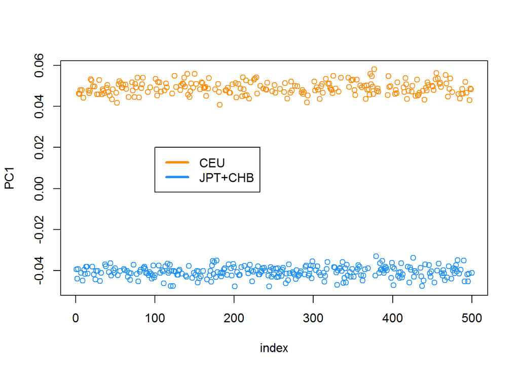

```r
# Now we want what population these PCs come from
pop = subject.support[controls, "stratum"]
plot(pcs[,1], col = as.numeric(pop), xlab = "index", ylab = "PC1")
legend(100,0.02, legend = levels(pop), col = 1:2, lwd = 3)
```

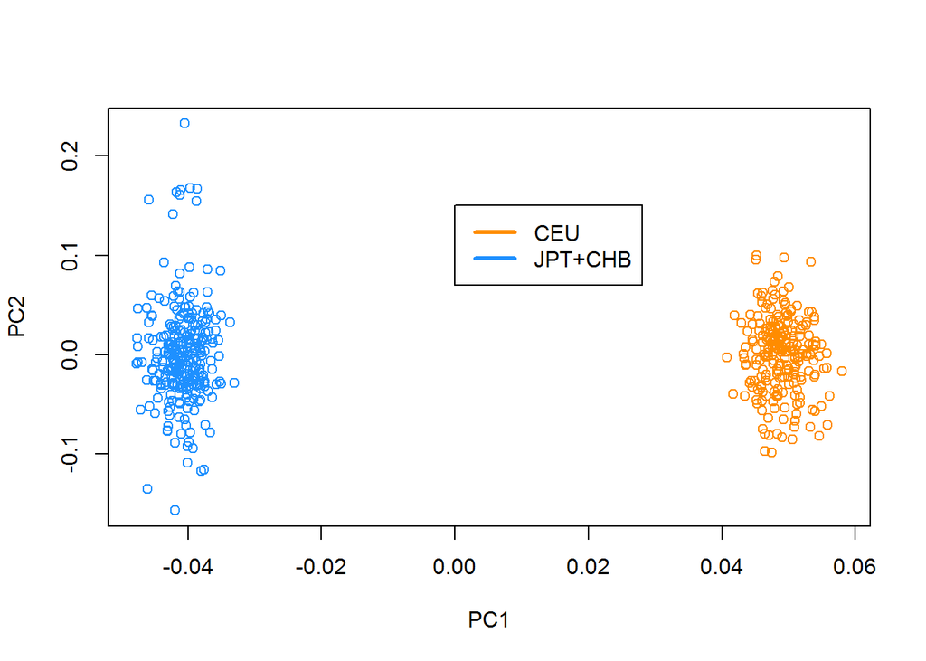

```r
plot(pcs[,1], pcs[,2], col = as.numeric(pop), xlab = "PC1", ylab = "PC2")
legend(0,0.15, legend = levels(pop), col = 1:2, lwd = 3)
```

We can say that major effect on genetics is due to the population. So, if disease is also associated with population, it could be a confounder. So the typical way that people deal with this is by using just direct principle component analysis, and PC for the adjustment. The reason being that the signal is often weak enough in genetic association studies that it’s not likely to be captured by the PC. And so you can just remove the PCs.

```
##  setting  value
##  version  R version 3.3.1 (2016-06-21)
##  system   x86_64, mingw32
##  ui       RTerm
##  language (EN)
##  collate  English_United States.1252
##  tz       America/New_York
##  date     2016-08-14
```

```
## Packages ------------------------------------------------------------------
```

[output not shown]

[output cut: 20 more lines]

[output not shown]

### Last compilation

Last compiled at 2016-08-14.